# Předmět: Bayesiánská analýza (MPE_BAAN)

Třetí úkol, příklad 2 (11.10 - 11.14) - skupina 13

2026-07-14

# ÚLOHA 2

*Zdroj: [Úvod k cvičeniam, kapitola 11](https://www.bayesrulesbook.com/chapter-11)*

> V nasledujúcich cvičeniach použijete dáta `penguins_bayes` z balíčka **bayesrules** na zostavenie rôznych modelov pre telesnú hmotnosť tučniakov (`body_mass_g`). Všade budeme využívať málo informatívne apriórne rozdelenia a základný predpoklad, že priemerný tučniak váži niekde medzi 3 500 a 4 500 gramami. Ďalej je jedným zo zaujímavých prediktorov druh tučniaka (`species`): Adelie, Chinstrap alebo Gentoo. Naše prvé skúsenosti s 3-úrovňovým prediktorom, ako je tento, získame v kapitole 12. Ak by ste chceli pracovať len s 2 úrovňami, ako ste to robili v kapitole 11, môžete využiť `penguin_data`, ktoré zahŕňajú len tučniakov druhov Adelie a Gentoo:

```
##   body_mass_g   flipper_length_mm bill_length_mm  bill_depth_mm
##  Min.   :2700   Min.   :172.0     Min.   :32.10   Min.   :13.10
##  1st Qu.:3550   1st Qu.:190.0     1st Qu.:39.23   1st Qu.:15.60
##  Median :4050   Median :197.0     Median :44.45   Median :17.30
##  Mean   :4202   Mean   :200.9     Mean   :43.92   Mean   :17.15
##  3rd Qu.:4750   3rd Qu.:213.0     3rd Qu.:48.50   3rd Qu.:18.70
##  Max.   :6300   Max.   :231.0     Max.   :59.60   Max.   :21.50
##  NA's   :2      NA's   :2         NA's   :2       NA's   :2
##       species
##  Adelie   :152
##  Chinstrap: 68
##  Gentoo   :124
##
##
##
##
```

# Příklad 11.10 (Penguins! Main effects)

*Zdroj: [Exercise 11.10](https://www.bayesrulesbook.com/chapter-11)*

> Začnime našu analýzu `body_mass_g` tučniakov preskúmaním jej vzťahu s `flipper_length_mm` a `species`.  
> **a)** Vykreslite a zhrňte pozorované vzťahy medzi týmito tromi premennými.  
> **b)** Použite `stan_glm()` na simuláciu posteriórneho modelu normálnej regresie pre `body_mass_g` na základe `flipper_length_mm` a `species`, a to bez interakčného člena.  
> **c)** Vytvorte a interpretujte vizuálnu aj numerickú diagnostiku vašej MCMC simulácie.  
> **d)** Vytvorte zhrnutie tohto modelu pomocou funkcie `tidy()`. Interpretujte v danom kontexte posteriórne mediány koeficientov (okrem interceptu).  
> **e)** Simulujte, vykreslite a opíšte posteriórny prediktívny model pre telesnú hmotnosť tučniaka druhu Adelie, ktorý má dĺžku plutvy 197.

## a) Pozorované vztahy mezi (dvěma) proměnnými

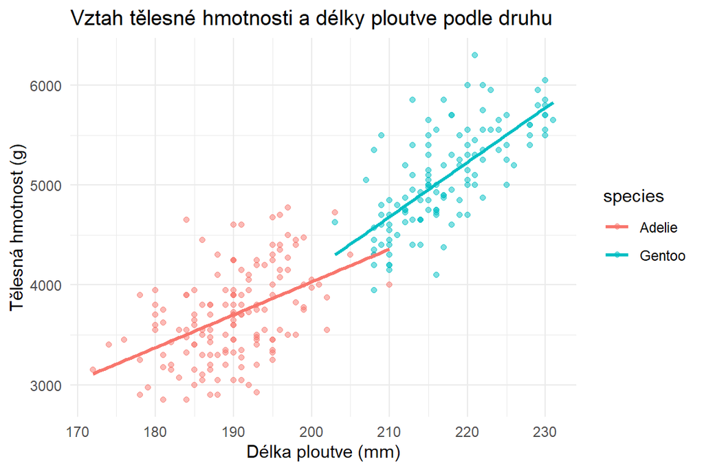

## b) Posteriorní normální regresní model

```r
posterior_penguins_1 <- stan_glm(body_mass_g ~ flipper_length_mm + species,
                            data = penguins_data, family = gaussian,
                            prior = normal(0, 2.5, autoscale = T),
                            prior_aux = exponential(1, autoscale = T),
                            prior_intercept = normal(location = 4000, scale = 1000, autoscale = T),
                            chains = 4, iter = 5000*2, refresh = 0, seed = 12345)
```

## c) Interpretace MCMC diagnostik

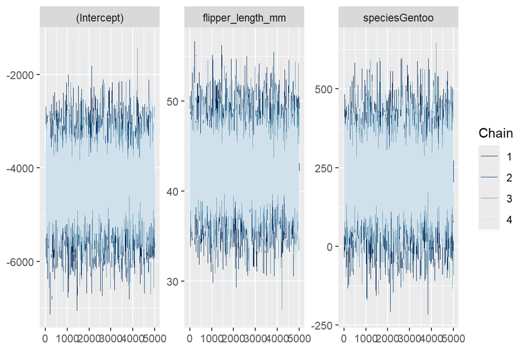

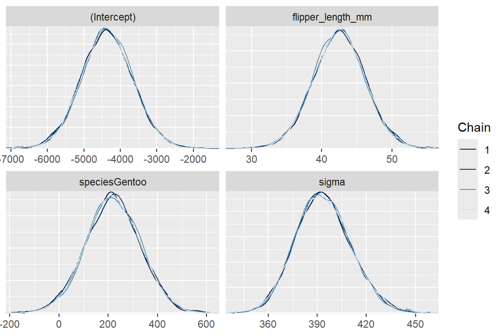

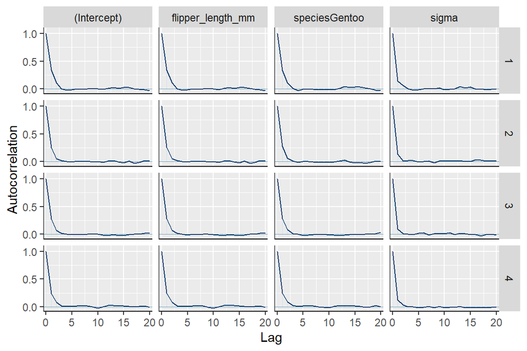

```
##       (Intercept) flipper_length_mm     speciesGentoo             sigma
##            0.5747            0.5696            0.5668            0.7532
```

```
##       (Intercept) flipper_length_mm     speciesGentoo             sigma
##          1.000037          1.000043          1.000080          1.000013
```

**Interpretace diagnostik:** Řetězce konvergovaly ke stejnému posteriornímu rozdělení dle hodnoty *rhat* blízko 1. V datech sice existuje jistá autokorelace, jelikož hodnoty *neff_ratia* jsou zhruba 0.5, nicméně i přesto máme dostatečný počet nezávislých odhadů pro další analýzu.

## d) Shrnutí a interpretace koeficientů

**Interpretace koeficientů:** Medián pro délku ploutve je *42.45 g/mm*, což znamená, že pokud dojde ke zvýšení ploutve o 1 mm, tak tělesná hmotnost se zvýší právě o danou hodnotu mediánu. Interval spolehlivosti neobsahuje nulu, tudíž délka ploutve a hmotnost mají pozitivní asociaci.Tučňák Gentoo má průměrně o *217.57* gramů vyšší váhu než druh Adelie, jelikož interval spolehlivosti opět neobsahuje nulu, tak tučňáci Gentoo jsou v průměru skutečně významně těžší.

## e) Posteriorní prediktivní model

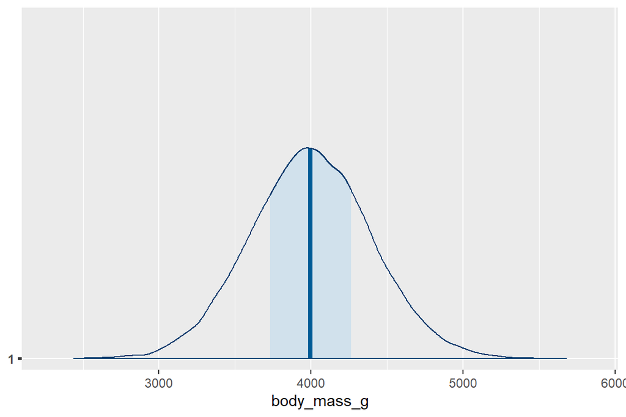

**Interpretace predikce:** Model nám predikuje, že nejpravděpodobnější hmotnost tohoto tučňáka se pohybuje okolo **4 000 gramů**. Celá křivka pokrývá poměrně široké rozmezí (cca 3 000 až 5 000 g). To je způsobeno tím, že predikujeme hodnotu pro jednoho konkrétního jedince, nikoliv průměr populace, a musíme tak do modelu zahrnout i přirozenou variabilitu, kterou model neodkáže vysvětlit pouze délkou ploutve a druhem.

# Příklad 11.11 (Penguins! Interaction)

*Zdroj: [Exercise 11.11](https://www.bayesrulesbook.com/chapter-11)*

> V nadväznosti na predchádzajúce cvičenie je naším ďalším cieľom modelovať `body_mass_g` na základe `flipper_length_mm` a `species` s interakčným členom medzi týmito dvoma prediktormi.  
> **a)** Použite `stan_glm()` na simuláciu posteriórneho modelu pre tento model, so 4 reťazcami s 10 000 iteráciami pre každý.  
> **b)** Simulujte a vykreslite 50 posteriórnych modelových priamok. Stručne popíšte, čo z tohto grafu zistíte.  
> **c)** Vytvorte zhrnutie tohto modelu pomocou funkcie `tidy()`. Máte na základe tohto zhrnutia dôkazy o tom, že interakčné členy sú pre tento model nevyhnutné? Vysvetlite vaše uvažovanie.

## a) Posteriorní model

```r
posterior_penguins_2 <- stan_glm(body_mass_g ~ flipper_length_mm + species + flipper_length_mm:species,
                                 data = penguins_data, family = gaussian,
                                 prior = normal(0, 2.5, autoscale = T),
                                 prior_intercept = normal(location = 4000, scale = 1000, autoscale = T),
                                 prior_aux = exponential(1, autoscale = TRUE),
                                 chains = 4, iter = 10000*2, refresh = 0, seed = 12345)
```

## b) Posteriorní modelové přímky

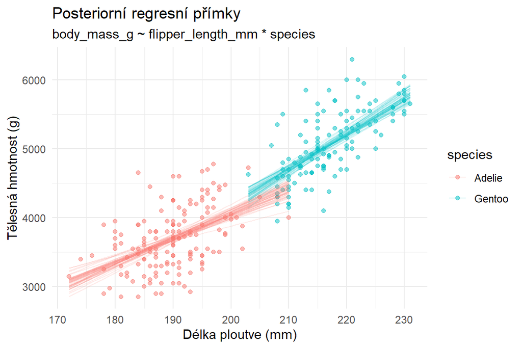

**Sumarizace:** Regresní přímky již nejsou zcela paralelní napříč druhy, tudíž vliv délky ploutve na tělesnou hmotnost závisí na pozorovaném druhu tučňáka.

## c) Souhrn, interakční členy

```
##                                     2.5%  97.5%
## flipper_length_mm:speciesGentoo 4.725295 29.852
```

**Interpretace:** Pokud budeme uvažovat čistě jen interakční člen mezi dvěma proměnnými, tak interval spolehlivosti neobsahuje 0, tudíž pro vysvětlování hmotnosti tučňáka má jistý přínos.

# Příklad 11.12 (Penguins! 3 predictors)

*Zdroj: [Exercise 11.12](https://www.bayesrulesbook.com/chapter-11)*

> Ďalej preskúmajme model `body_mass_g` s využitím troch prediktorov: `flipper_length_mm`, `bill_length_mm` a `bill_depth_mm`. Nepoužívajte v tomto modeli žiadne interakcie.  
> **a)** Použite `stan_glm()` na simuláciu posteriórneho modelu pre tento model.  
> **b)** Použite `posterior_interval()` na vytvorenie 95% kredibilných intervalov pre parametre modelu.  
> **c)** Na základe týchto 95% kredibilných intervalov – pri kontrolovaní ostatných prediktorov v modeli – ktoré prediktory majú významnú pozitívnu asociáciu s telesnou hmotnosťou, ktoré majú významnú negatívnu asociáciu s telesnou hmotnosťou a ktoré nemajú žiadnu významnú asociáciu?

## a) Simulace modelu

```r
posterior_penguins_3 <- stan_glm(body_mass_g ~ flipper_length_mm + bill_length_mm + bill_depth_mm,
                                 data = penguins_data,
                                 family = gaussian,
                                 prior_intercept = normal(4000, 1000),
                                 prior = normal(0, 2.5, autoscale = TRUE),
                                 prior_aux = exponential(1, autoscale = TRUE),
                                 chains = 4, iter = 5000*2, refresh = 0, seed = 12345)
```

## b) Posteriorní intervaly spolehlivosti (95%)

```
##                          2.5%       97.5%
## (Intercept)       -7239.53340 -5058.12315
## flipper_length_mm    26.24152    38.14767
## bill_length_mm       55.76988    87.26963
## bill_depth_mm        28.11354    79.91875
## sigma               312.42360   368.94271
```

## c) Interpretace asociací s prediktory

**Pri kontrole ostatných prediktorov:**

- **Pozitivní asociace:** `flipper_length_mm`, `bill_length_mm`, `bill_depth_mm`
- **Negativní asociace:** *žádná*
- **Žádná signifikantní asociace:** *Ano, jelikož žádný interval spohlivosti pro prediktor v sobě nezahrnuje nulu.*

# Příklad 11.13 (Penguins! Comparing models)

*Zdroj: [Exercise 11.13](https://www.bayesrulesbook.com/chapter-11)*

> Zvážte štyri možné modely pre `body_mass_g`:  
> | model | formula |  
> | 1 | `body_mass_g ~ flipper_length_mm` |  
> | 2 | `body_mass_g ~ species` |  
> | 3 | `body_mass_g ~ flipper_length_mm + species` |  
> | 4 | `body_mass_g ~ flipper_length_mm + bill_length_mm + bill_depth_mm` |  
> **a)** Simulujte tieto štyri modely pomocou funkcie `stan_glm()`.  
> **b)** Vytvorte a porovnajte grafy `pp_check()` pre tieto štyri modely.  
> **c)** Použite 10-násobnú krížovú validáciu na vyhodnotenie a porovnanie posteriórnej prediktívnej kvality štyroch modelov pomocou `prediction_summary_cv()`. POZNÁMKA: Telesnú hmotnosť dokážeme predikovať len pre tučniaky, ktoré majú kompletné informácie o prediktoroch nášho modelu. Napriek tomu dvom tučniakom chýbajú hodnoty (NA) pre viaceré z týchto prediktorov. Ak chceme tieto dva tučniaky odstrániť, pomocou `select()` vyberieme len stĺpce nášho záujmu predtým, ako odstránime tučniaky s chýbajúcimi hodnotami. Týmto spôsobom nezahodíme dáta o tučniakoch len preto, že im chýbajú informácie o premenných, o ktoré sa nezaujímame.  
> **d)** Vyhodnoťte a porovnajte posteriórnu prediktívnu presnosť pomocou ELPD pre tieto štyri modely.  
> **e)** Ktorý z týchto štyroch modelov je podľa vášho zhrnutia “najlepší?” Vysvetlite.

## a) Definice a simulace modelů

```r
# Model 1: body_mass_g ~ flipper_length_mm

model_1 <- stan_glm(body_mass_g ~ flipper_length_mm,
                    data = penguins_data, family = gaussian,
                    prior_intercept = normal(4000, 1000),
                    prior = normal(0, 2.5, autoscale = T),
                    prior_aux = exponential(1,autoscale = T),
                    chains = 4, iter = 5000*2, seed = 12345, refresh = 0)

# Model 2: body_mass_g ~ species

model_2 <- stan_glm(body_mass_g ~ species,
                    data = penguins_data, family = gaussian,
                    prior_intercept = normal(4000, 1000),
                    prior = normal(0, 2.5, autoscale = T),
                    prior_aux = exponential(1,autoscale = T),
                    chains = 4, iter = 5000*2, seed = 12345, refresh = 0)

# Model 3: body_mass_g ~ flipper_length_mm + species

model_3 <- stan_glm(body_mass_g ~ flipper_length_mm + species,
                    data = penguins_data, family = gaussian,
                    prior_intercept = normal(4000, 1000),
                    prior = normal(0, 2.5, autoscale = T),
                    prior_aux = exponential(1,autoscale = T),
                    chains = 4, iter = 5000*2, seed = 12345, refresh = 0)

# Model 4: body_mass_g ~ flipper_length_mm + bill_length_mm + bill_depth_mm

model_4 <- stan_glm(body_mass_g ~ flipper_length_mm + bill_length_mm + bill_depth_mm,
                    data = penguins_data, family = gaussian,
                    prior_intercept = normal(4000, 1000),
                    prior = normal(0, 2.5, autoscale = T),
                    prior_aux = exponential(1,autoscale = T),
                    chains = 4, iter = 5000*2, seed = 12345, refresh = 0)
```

## b) Posteriorní prediktivní kontroly (checks)

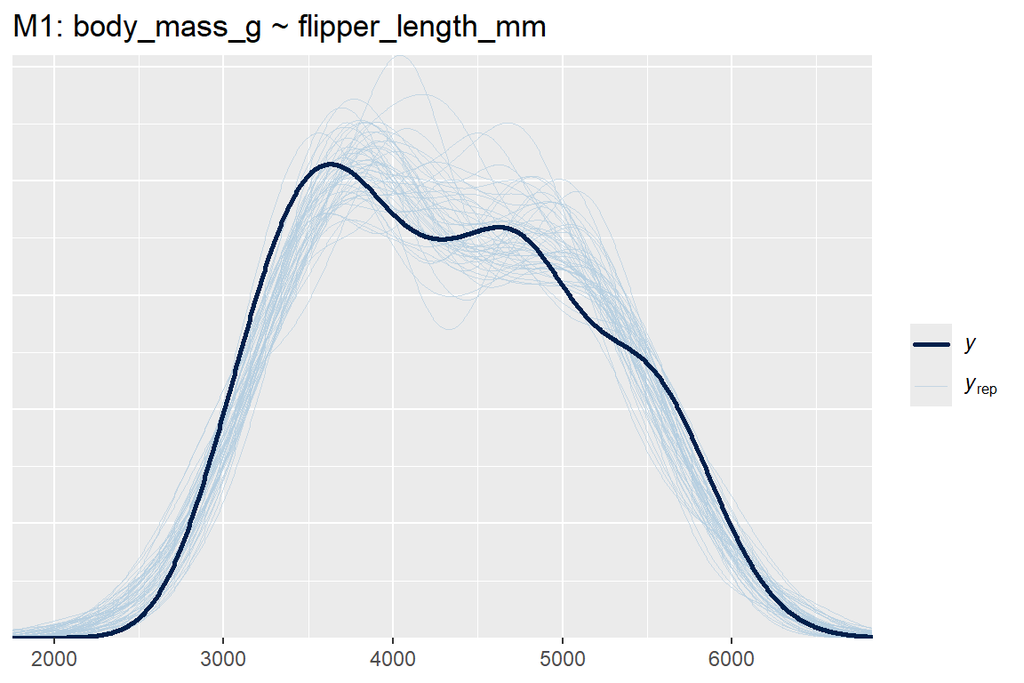

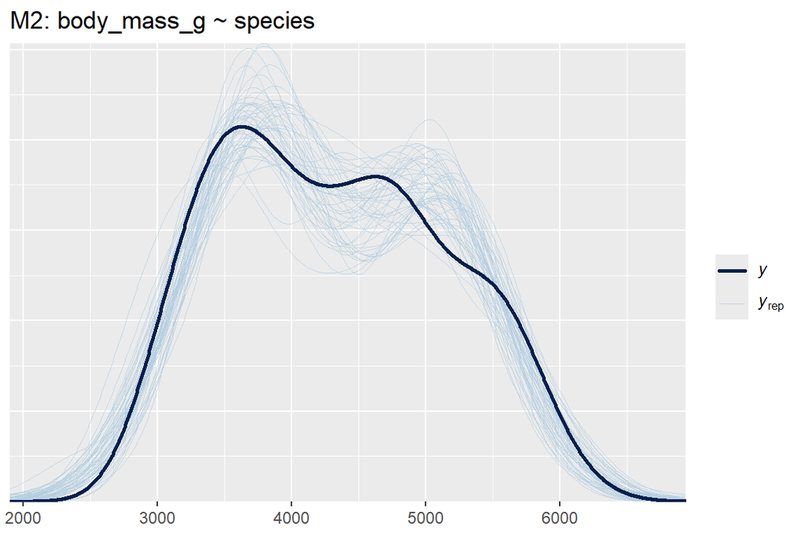

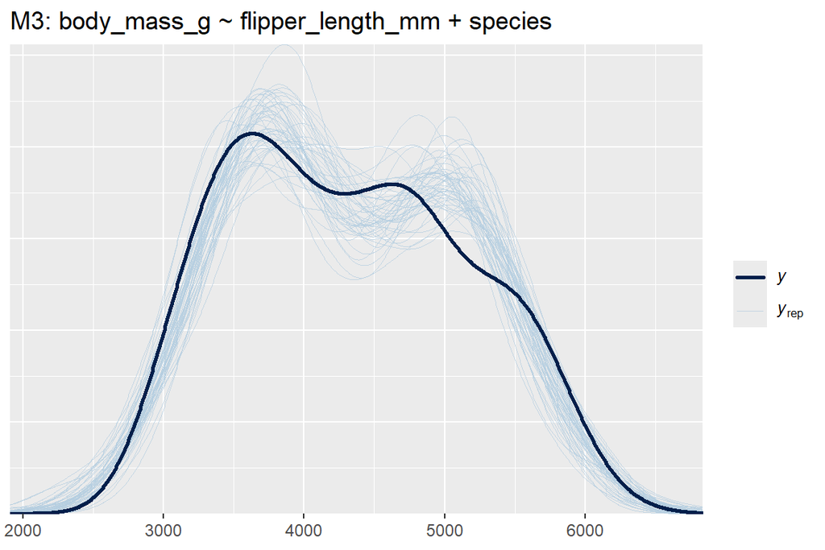

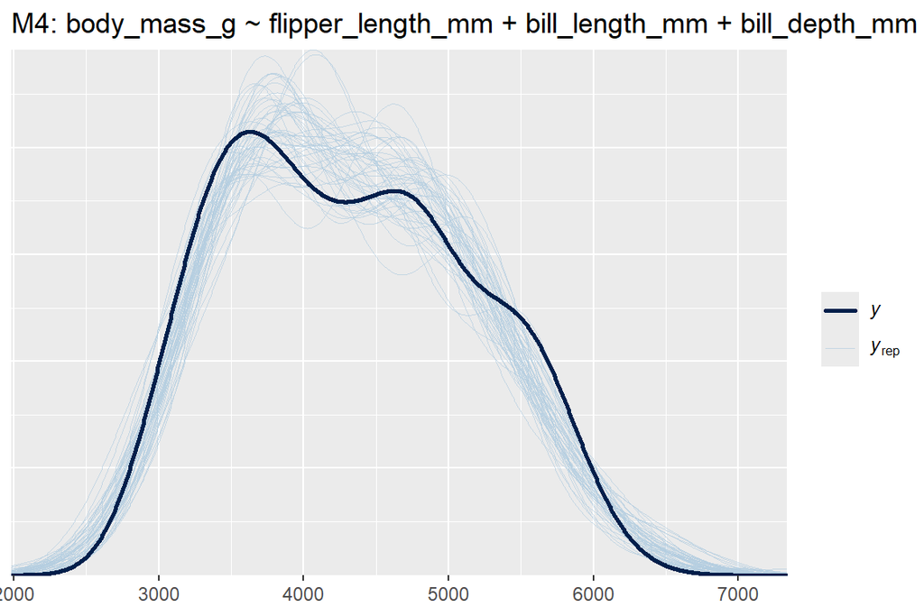

## d) ELPD porovnání

```
##         elpd_diff se_diff
## model_4   0.0       0.0
## model_3 -40.0       7.4
## model_1 -41.0       7.1
## model_2 -94.6      11.4
```

**Interpretace ELPD:** Porovnání modelů pomocí ELPD potvrzuje dominanci Modelu 4, který se umístil na prvním místě. Rozdíl mezi ním a druhým Modelem 3 je `elpd_diff` = **-40,0** se standardní chybou `se_diff` = **7,4**. Jelikož je rozdíl výrazně větší než dvojnásobek standardní chyby, můžeme s jistotou říci, že Model 4 má signifikantně lepší prediktivní schopnost než tři ostatní modely. Zároveň vidíme, že mezi Modelem 3 (*-40,0*) a Modelem 1 (*-41,0*) je rozdíl zanedbatelný, což znovu naznačuje, že v kontextu ELPD nepřináší modelování druhu (`species`) nad rámec délky ploutve (`flipper_length_mm`) žádnou zásadní výhodu.

# Příklad 11.14 (Penguins on your own)

*Zdroj: [Exercise 11.14](https://www.bayesrulesbook.com/chapter-11)*

> Vytvorte tri rôzne modely pre dĺžku zobáka tučniaka `bill_length_mm`. Môžete si vybrať, ktoré prediktory použijete a či zahrniete aj interakčné členy. Vyhodnoťte a porovnajte tieto modely. Ktorý preferujete a prečo?

## Návrh modelů

> 1 | `bill_length ~ bill_depth_mm` |  
> 2 | `bill_length ~ bill_depth_mm + flipper_length_mm` |  
> 3 | `bill_length ~ bill_depth_mm + flipper_length_mm + body_mass_g` |

**Zdůvodnění výběru prediktorů:** V této analýze jsme se záměrně odklonili od kategorického dělení podle druhů (`species`) a zaměřili jsme se čistě na vlastnosti těla tučňáka. Modely jsou záměrně postupně obohacovány o další prediktory a jsou rovněž vynechány kategorické proměnné pro obecnější výsledky naší analýzy oproti předchozím modelům v rámci minulých příkladů.

## Implementace modelů

```r
# Model 1: bill_length_mm ~ bill_depth_mm

my_model1 <- stan_glm(bill_length_mm ~ bill_depth_mm,
                     data = penguins_data, family = gaussian,
                     prior_intercept = normal(45, 10),
                     prior = normal(0, 2.5, autoscale = TRUE),
                     prior_aux = exponential(1, autoscale = TRUE),
                     chains = 4, iter = 10000*2, seed = 12345, refresh = 0)

# Model 2: bill_length_mm ~ bill_depth_mm + flipper_length_mm

my_model2 <- stan_glm(bill_length_mm ~ bill_depth_mm + flipper_length_mm,
                     data = penguins_data, family = gaussian,
                     prior_intercept = normal(45, 10),
                     prior = normal(0, 2.5, autoscale = TRUE),
                     prior_aux = exponential(1, autoscale = TRUE),
                     chains = 4, iter = 10000*2, seed = 12345, refresh = 0)

# Model 3: bill_length_mm ~ bill_depth_mm + flipper_length_mm + body_mass_g

my_model3 <- stan_glm(bill_length_mm ~ bill_depth_mm + flipper_length_mm + body_mass_g,
                     data = penguins_data, family = gaussian,
                     prior_intercept = normal(45, 10),
                     prior = normal(0, 2.5, autoscale = TRUE),
                     prior_aux = exponential(1, autoscale = TRUE),
                     chains = 4, iter = 10000*2, seed = 12345, refresh = 0)
```

## Evaluace modelu

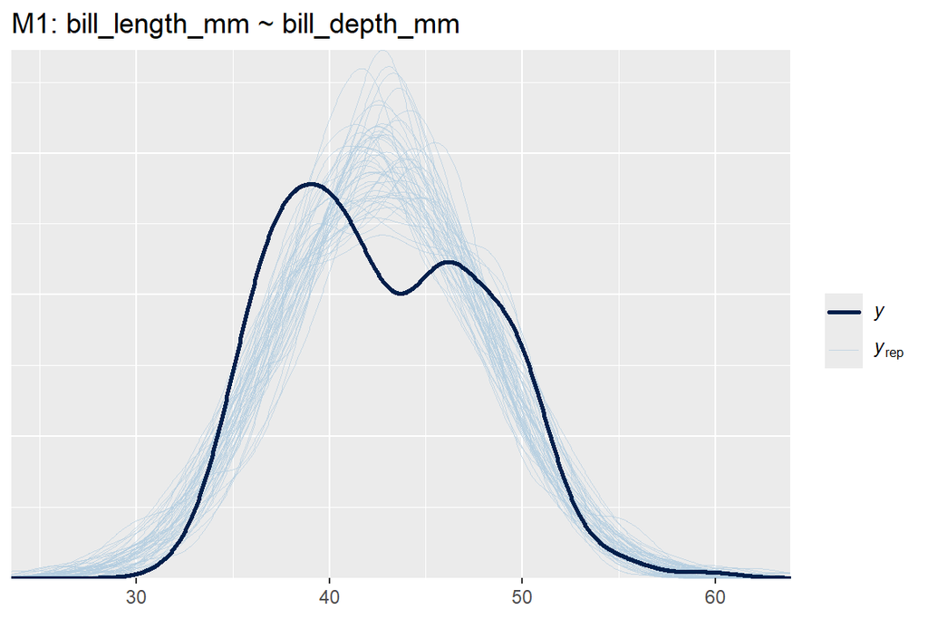

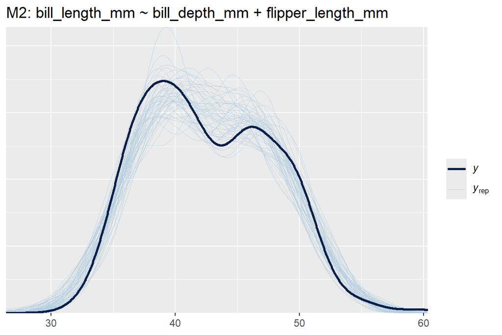

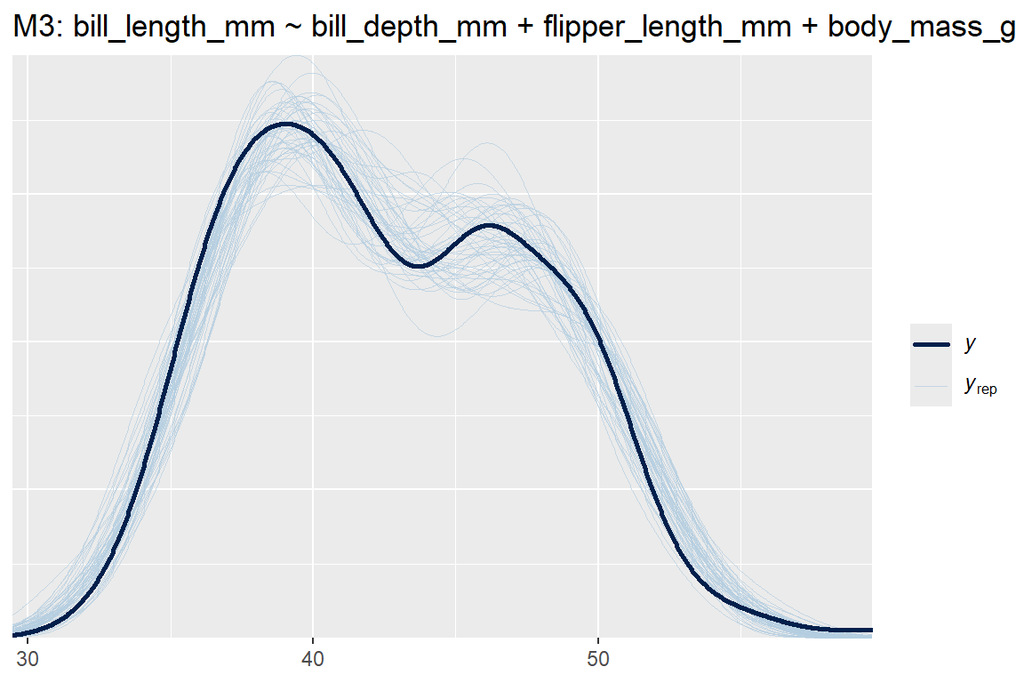

```
##           elpd_diff se_diff
## my_model3    0.0       0.0
## my_model2  -34.7       6.9
## my_model1 -177.9      13.3
```